# Prediction Assignment Write-up

Arindam Biswas

October 25, 2015

## Executive Summary

Using devices such as Jawbone Up, Nike FuelBand, and Fitbit it is now possible to collect a large amount of data about personal activity relatively inexpensively. People regularly quantify how much of a particular activity they do, but they rarely quantify how well they do it.

In this project, we will use data from accelerometers on the belt, forearm, arm, and dumbell of 6 participants, who were asked to perform barbell lifts correctly and incorrectly in 5 different ways. More information is available from the website here: http://groupware.les.inf.puc-rio.br/har.

The goal of your project is to predict the manner in which they did the exercise. We implement the Random Forests model. Before apply the prediction model on the data-set, we clean the data by performing various data cleansing steps.

## Prepare the Environment and Load Libraries

First we prepare the environment and load the required libraries for the predictive modelling and set seed

```r
library(caret)
library(randomForest)
library(parallel)
library(doParallel)
set.seed(1234)
```

## Load Data

The training data for this project is available [here](https://d396qusza40orc.cloudfront.net/predmachlearn/pml-training.csv) and the test data [here](https://d396qusza40orc.cloudfront.net/predmachlearn/pml-testing.csv)

```r
#set the URLs of the training and testing data
trainurl ="https://d396qusza40orc.cloudfront.net/predmachlearn/pml-training.csv"
testurl = "https://d396qusza40orc.cloudfront.net/predmachlearn/pml-testing.csv"

#set the names of the training and test data
trainname = "pml-training.csv"
testname = "pml-testing.csv"

#if the data files do not exist, download the files
if (!file.exists(trainname)) {
  download.file(trainurl, destfile=trainname, method="curl")
}

if (!file.exists(testname)) {
  download.file(testurl, destfile=testname, method="curl")
}

# load the CSV files as data.frame
train = read.csv("pml-training.csv", header=TRUE, sep=",", na.strings=c("", "NA", "NULL"))
test = read.csv("pml-testing.csv", header=TRUE, sep=",", na.strings=c("", "NA", "NULL"))
```

## Data Exploration and Cleansing

```r
str(train)
head(train,5)
```

```r
dim(train)
```

```
## [1] 19622   160
```

```r
dim(test)
```

```
## [1]  20 160
```

The raw training data has 19622 rows of observations and 160 columns. While the testing data has 20 rows and 160 columns. There is one column/variable to predict named `classe`.

After studying the training data, we perform the below cleansing of the data:

- Remove variables that have too many NA values (less than 80% of data filled)
- Remove variables not relevant for classification (`X`, `user_name`, `raw_timestamp_part_1`, `raw_timestamp_part_2`, `cvtd_timestamp`, `new_window`, `num_window`)
- Remove variables that have extremely low variance
- Convert `classe` into factor

```r
#remove variables with less than 80% of data filled
filled <- c((colSums(!is.na(train[,-ncol(train)])) >= 0.8*nrow(train)))
train <- train[,filled]
test <- test[,filled]
dim(train)
```

```
## [1] 19622    60
```

```r
#remove variables not relevant for classification
nonrelevant = c('X', 'user_name', 'raw_timestamp_part_1', 'raw_timestamp_part_2', 'cvtd_timestamp', 'new_window', 'num_window')
train <- train[, -which(names(train) %in% nonrelevant)]
test <- test[, -which(names(test) %in% nonrelevant)]

#remove variables that have extremely low variance
lowVar <- nearZeroVar(train[sapply(train, is.numeric)], saveMetrics = TRUE)
train <- train[, lowVar$nzv==FALSE]
test <- test[, lowVar$nzv==FALSE]

#convert classe into factor
train$classe <- factor(train$classe)
dim(train)
```

```
## [1] 19622    53
```

The cleansed training data has 19622 rows of observations and 53 columns.

## Splitting Data

Split the train data into two partitions of training and validating data sets in the ratio 70:30.

```r
split <- createDataPartition(y=train$classe, p=0.7, list=FALSE)
trainPart <- train[split,]
validPart <- train[-split,]
dim(trainPart)
```

```
## [1] 13737    53
```

```r
dim(validPart)
```

```
## [1] 5885   53
```

We get 13737 samples and 53 variables for training, 5885 samples and 53 variables for validating

## Modelling and Evaluation

Now we use the Random Forest model on the trainPart data split.

```r
rfmodel <- randomForest(classe~., data=trainPart, importance = TRUE)
rfmodel
```

```
##
## Call:
##  randomForest(formula = classe ~ ., data = trainPart, importance = TRUE)
##                Type of random forest: classification
##                      Number of trees: 500
## No. of variables tried at each split: 7
##
##         OOB estimate of  error rate: 0.47%
## Confusion matrix:
##      A    B    C    D    E  class.error
## A 3903    2    0    0    1 0.0007680492
## B   12 2641    5    0    0 0.0063957863
## C    0   11 2383    2    0 0.0054257095
## D    0    0   23 2227    2 0.0111012433
## E    0    0    2    5 2518 0.0027722772
```

Our Random Forest model shows OOB estimate of error rate: 0.47% for the training data.

Now we verify the variable importance measures as produced by random Forest.

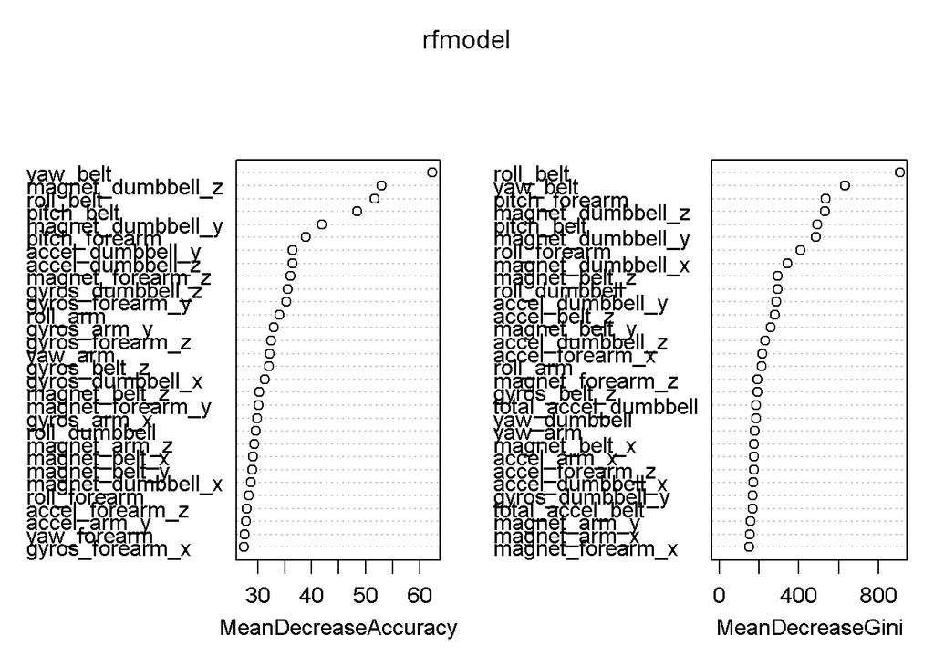

```r
varImpPlot(rfmodel)
```

From the plots we see which variables have higher impact on the prediction.

## Out-of Sample Error

The Random Forest model shows OOB estimate of error rate: 0.47% for the training data split. Now we will predict it for out-of sample accuracy by evaluating our model results through confusion Matrix on the validation data split.

```r
confusionMatrix(predict(rfmodel,newdata=validPart[,-ncol(validPart)]),validPart$classe)
```

```
## Confusion Matrix and Statistics
##
##           Reference
## Prediction    A    B    C    D    E
##          A 1674    6    0    0    0
##          B    0 1132    6    0    0
##          C    0    1 1020    4    0
##          D    0    0    0  959    0
##          E    0    0    0    1 1082
##
## Overall Statistics
##
##                Accuracy : 0.9969
##                  95% CI : (0.9952, 0.9982)
##     No Information Rate : 0.2845
##     P-Value [Acc > NIR] : < 2.2e-16
##
##                   Kappa : 0.9961
##  Mcnemar's Test P-Value : NA
##
## Statistics by Class:
##
##                      Class: A Class: B Class: C Class: D Class: E
## Sensitivity            1.0000   0.9939   0.9942   0.9948   1.0000
## Specificity            0.9986   0.9987   0.9990   1.0000   0.9998
## Pos Pred Value         0.9964   0.9947   0.9951   1.0000   0.9991
## Neg Pred Value         1.0000   0.9985   0.9988   0.9990   1.0000
## Prevalence             0.2845   0.1935   0.1743   0.1638   0.1839
## Detection Rate         0.2845   0.1924   0.1733   0.1630   0.1839
## Detection Prevalence   0.2855   0.1934   0.1742   0.1630   0.1840
## Balanced Accuracy      0.9993   0.9963   0.9966   0.9974   0.9999
```

We observe that the Random Forest model accuracy as tested over Validation data split is 99.69%, which is a very good accuracy level.

## Cross Validation

```r
registerDoParallel(makeCluster(detectCores()))
controlCV <- trainControl(method = "repeatedcv", number = 10, repeats = 10)
rfmodel_CV <- randomForest(classe~., data=trainPart, importance = TRUE, trControl = controlCV)
```

```r
confusionMatrix(predict(rfmodel_CV,newdata=validPart[,-ncol(validPart)]),validPart$classe)
```

```
## Confusion Matrix and Statistics
##
##           Reference
## Prediction    A    B    C    D    E
##          A 1674    5    0    0    0
##          B    0 1133    7    0    0
##          C    0    1 1019    4    0
##          D    0    0    0  959    1
##          E    0    0    0    1 1081
##
## Overall Statistics
##
##                Accuracy : 0.9968
##                  95% CI : (0.995, 0.9981)
##     No Information Rate : 0.2845
##     P-Value [Acc > NIR] : < 2.2e-16
##
##                   Kappa : 0.9959
##  Mcnemar's Test P-Value : NA
##
## Statistics by Class:
##
##                      Class: A Class: B Class: C Class: D Class: E
## Sensitivity            1.0000   0.9947   0.9932   0.9948   0.9991
## Specificity            0.9988   0.9985   0.9990   0.9998   0.9998
## Pos Pred Value         0.9970   0.9939   0.9951   0.9990   0.9991
## Neg Pred Value         1.0000   0.9987   0.9986   0.9990   0.9998
## Prevalence             0.2845   0.1935   0.1743   0.1638   0.1839
## Detection Rate         0.2845   0.1925   0.1732   0.1630   0.1837
## Detection Prevalence   0.2853   0.1937   0.1740   0.1631   0.1839
## Balanced Accuracy      0.9994   0.9966   0.9961   0.9973   0.9994
```

## Predict on Test Data

Finally, we predict the new values using the model on the testing csv provided.

```r
predictions <- predict(rfmodel,newdata=test)
```